# Assisting children while biking

### Gruppe 7: Maximilian Hörnis, Florian Schwarm, Dennis Rupprecht

## Motivation

- Children are active participants in road traffic
- Traffic signs might not be obvious to them
- Handheld technology device (smartphones etc.) usage is prevalent among children

## Idea

Recognize and classify traffic signs automatically and display them in an easy to understand assistive technology for children, without distracting them.

## Problems

- It is difficult to find the right boundaries for the colours
- Other traffic signs are difficult to recognise with this method
- Many rules have to be established and queried

## Task

- Recognize more signs
- Proof of the Problems

## Selection from traffic signs:

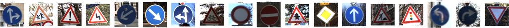

```python
show_images(images)
```

## Recognize a stop sign

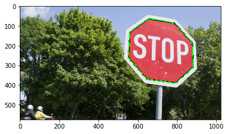

```python
plt.imshow(img)
cv2.waitKey(0)
cv2.destroyAllWindows()
```

## Recognize more signs

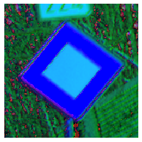

```python
image12 = cv2.imread("img/12.png")
image12 = cv2.cvtColor(image12, cv2.COLOR_BGR2RGB)
image12_hsv = cv2.cvtColor(image12, cv2.COLOR_RGB2HSV)
fig = plt.figure()
plt.axis("off")
plt.imshow(image12_hsv)
```

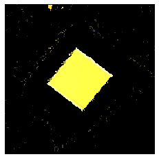

```python
# Define the colors.
lower_yellow = np.array([25,50,50])
upper_yellow = np.array([32,255,255])

mask2 = cv2.inRange(image12_hsv, lower_yellow, upper_yellow)

output2 = cv2.bitwise_and(image12, image12, mask=mask2)

plt.axis("off")
plt.imshow(output2)
```

```python
contours, _ = cv2.findContours(mask2, cv2.RETR_TREE, cv2.CHAIN_APPROX_SIMPLE)

#draw contours and check if this has 8 nodes
for cnt in contours:
    area = cv2.contourArea(cnt)
    # Shortlisting the regions based on there area.
    if area > 1000:
        # approxPolyDP(image, epsilon, closed)
        # epsilon is the approximation accuracy/ specified precision
        # arcLength(image, closed) is the size of the image
        approx = cv2.approxPolyDP(cnt,
                                  0.02 * cv2.arcLength(cnt, True), True)
        x = approx.ravel()[0]
        y = approx.ravel()[1]
        if len(approx)==4:
            print("This is a priority sign!")
            cv2.drawContours(image12,[cnt],0,(0,255,0),3)
        else:
            print("Nothing to see here")
```

```
This is a priority sign!
```

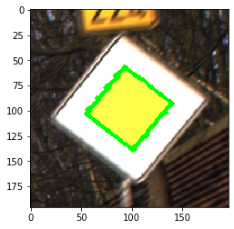

```python
plt.imshow(image12)
cv2.waitKey(0)
cv2.destroyAllWindows()
```

```python
image06 = cv2.imread("img/06.png")
image06 = cv2.cvtColor(image06, cv2.COLOR_BGR2RGB)
image06_hsv = cv2.cvtColor(image06, cv2.COLOR_RGB2HSV)
# Define the colors.
lower_blue = np.array([0,160,160])
upper_blue = np.array([120,255,255])
mask3 = cv2.inRange(image06_hsv, lower_blue, upper_blue)

output3 = cv2.bitwise_and(image06, image06, mask=mask3)
output3_gray = cv2.cvtColor(output3, cv2.COLOR_BGR2GRAY)
img_blur = cv2.medianBlur(output3_gray, 5)
contours, _ = cv2.findContours(mask3, cv2.RETR_TREE, cv2.CHAIN_APPROX_SIMPLE)
```

```
17
Nothing to see here
```

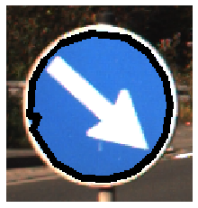

```python
for cnt in contours:
    area = cv2.contourArea(cnt)
    if area > 2000:
        # approxPolyDP(image, epsilon, closed)
        # epsilon is the approximation accuracy/ specified precision
        # arcLength(image, closed) is the size of the image
        approx = cv2.approxPolyDP(cnt,
                                   0.009 * cv2.arcLength(cnt, True), True)
        cv2.drawContours(image06, [approx], 0, (0), 3)
        x = approx.ravel()[0]
        y = approx.ravel()[1]
        print(len(approx))
        if len(approx)==0:
            print("This is a blue round sign!")
        else:
            print("Nothing to see here")
fig = plt.figure()
plt.axis("off")
plt.imshow(image06)
```

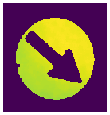

```python
image06 = cv2.imread("img/06.png")
image06 = cv2.cvtColor(image06, cv2.COLOR_BGR2RGB)
image06_hsv = cv2.cvtColor(image06, cv2.COLOR_RGB2HSV)
fig = plt.figure()

# Define the colors.
lower_blue = np.array([0,160,160])
upper_blue = np.array([120,255,255])
mask3 = cv2.inRange(image06_hsv, lower_blue, upper_blue)

output3 = cv2.bitwise_and(image06, image06, mask=mask3)
output3_gray = cv2.cvtColor(output3, cv2.COLOR_BGR2GRAY)
img_blur = cv2.medianBlur(output3_gray, 5)
plt.axis("off")
plt.imshow(img_blur)
```

```
There is a blue round circle!
```

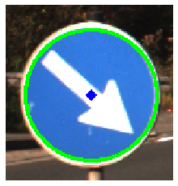

```python
# HoughCircles(image, method, dp, min_dist,param1, param2, minRadius) https://docs.opencv.org/2.4/doc/tutorials/imgproc/imgtrans/hough_circle/hough_circle.html - https://www.youtube.com/watch?v=dp1r9oT_h9k
# dp = The inverse ratio of resolution
# min_dist = distence between two center
# param_1 = Threshold for Canny edge detector
# param_2 = Threshold for center detection
circles = cv2.HoughCircles(img_blur, cv2.HOUGH_GRADIENT, 1, 100, param1=50, param2=10, minRadius=50)
# Draw detected circles
if circles is not None:
    circles = np.uint16(np.around(circles))
    for i in circles[0, :]:
        # Draw outer circle
        cv2.circle(image06, (i[0], i[1]), i[2], (0, 255, 0), 2)
        # Draw center of the circle
        cv2.circle(image06, (i[0], i[1]), 2, (0, 0, 255), 3)
        print("There is a blue round circle!")
else:
    print("Nothing to see here!")
plt.axis("off")
plt.imshow(image06)
```

```
Nothing to see here!
```

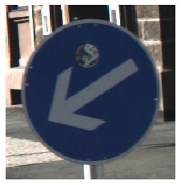

```python
# Draw detected circles
if circles is not None:
    circles = np.uint16(np.around(circles))
    for i in circles[0, :]:
        # Draw outer circle
        cv2.circle(image_problem, (i[0], i[1]), i[2], (0, 255, 0), 2)
        # Draw center of the circle
        cv2.circle(image_problem, (i[0], i[1]), 2, (0, 0, 255), 3)
        print("This is a blue round circle!")
else:
    print("Nothing to see here!")
plt.axis("off")
plt.imshow(image_problem)
```

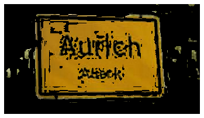

```python
problem_test = cv2.imread("img/problem_test.jpg")
problem_test = cv2.cvtColor(problem_test, cv2.COLOR_BGR2RGB)
problem_test_hsv = cv2.cvtColor(problem_test, cv2.COLOR_RGB2HSV)
# Define the colors.
lower_yellow = np.array([20,50,50])
upper_yellow = np.array([32,255,255])

mask5 = cv2.inRange(problem_test_hsv, lower_yellow, upper_yellow)

output5 = cv2.bitwise_and(problem_test, problem_test, mask=mask5)

contours, _ = cv2.findContours(mask5, cv2.RETR_TREE, cv2.CHAIN_APPROX_SIMPLE)
plt.axis("off")
plt.imshow(output5)
```

```
This is a priority sign!
Nothing to see here
```

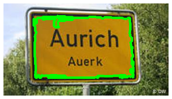

```python
#draw contours and check if this has 8 nodes
for cnt in contours:
    area = cv2.contourArea(cnt)
    # Shortlisting the regions based on there area.
    if area > 1000:
        # approxPolyDP(image, epsilon, closed)
        # epsilon is the approximation accuracy/ specified precision
        # arcLength(image, closed) is the size of the image
        approx = cv2.approxPolyDP(cnt,
                                  0.02 * cv2.arcLength(cnt, True), True)
        x = approx.ravel()[0]
        y = approx.ravel()[1]
        problem_test_1 = problem_test
        if len(approx)==4:
            print("This is a priority sign!")
            cv2.drawContours(problem_test,[cnt],0,(0,255,0),3)
        else:
            print("Nothing to see here")
fig = plt.figure()
plt.axis("off")
plt.imshow(problem_test)
```

## Problems

It is difficult to find the right boundaries for the colours

- blue signs: one detected, one not detected

Other traffic signs are difficult to recognise with this method

- yellow signs: both detected

Many rules have to be established and queried

- if red: 8 edges or (3 edges and (somthing in it or (nothing and reversed))) or round
- if yellow: 4 edges and ...
- if blue: round or 4 edges ...